# HEART DISEASE PREDICTIONS (LOGISTIC REGRESSION MODEL)

Ajinkya

2024-12-24

```r
# Load the tidyverse package, which includes useful packages for data manipulation and visualization

library(tidyverse)
```

# Step 1: Read the heart.csv file from the specified file path and store the data in the ‘heart’ data frame

```r
heart <- read_csv("C:/Users/Ajinkyaa/OneDrive/Stata to R/New folder/HEART DISEASE PREDICTION MODEL/heart.csv")
```

# Step 2: Data Exploration, to Understand data structure, identify problems (missing/duplicate values), and ensure data integrity

```r
view(heart) #Browse the all loaded data
head(heart) #Viewing the First Few Rows
```

```
## # A tibble: 6 × 14
##     age   sex    cp trestbps  chol   fbs restecg thalach exang oldpeak slope
##   <dbl> <dbl> <dbl>    <dbl> <dbl> <dbl>   <dbl>   <dbl> <dbl>   <dbl> <dbl>
## 1    52     1     0      125   212     0       1     168     0     1       2
## 2    53     1     0      140   203     1       0     155     1     3.1     0
## 3    70     1     0      145   174     0       1     125     1     2.6     0
## 4    61     1     0      148   203     0       1     161     0     0       2
## 5    62     0     0      138   294     1       1     106     0     1.9     1
## 6    58     0     0      100   248     0       0     122     0     1       1
## # ℹ 3 more variables: ca <dbl>, thal <dbl>, target <dbl>
```

```r
glimpse(heart) #Summarizing Data Structure (Provides an overview of the dataset, including the number of rows and columns, data types (numeric, categorical, etc.), and a sample of the data in each column)
```

```
## Rows: 1,025
## Columns: 14
## $ age      <dbl> 52, 53, 70, 61, 62, 58, 58, 55, 46, 54, 71, 43, 34, 51, 52, 3…
## $ sex      <dbl> 1, 1, 1, 1, 0, 0, 1, 1, 1, 1, 0, 0, 0, 1, 1, 0, 0, 1, 0, 1, 1…
## $ cp       <dbl> 0, 0, 0, 0, 0, 0, 0, 0, 0, 0, 0, 0, 1, 0, 0, 1, 2, 0, 1, 2, 2…
## $ trestbps <dbl> 125, 140, 145, 148, 138, 100, 114, 160, 120, 122, 112, 132, 1…
## $ chol     <dbl> 212, 203, 174, 203, 294, 248, 318, 289, 249, 286, 149, 341, 2…
## $ fbs      <dbl> 0, 1, 0, 0, 1, 0, 0, 0, 0, 0, 0, 1, 0, 0, 1, 0, 0, 0, 0, 1, 0…
## $ restecg  <dbl> 1, 0, 1, 1, 1, 0, 2, 0, 0, 0, 1, 0, 1, 1, 1, 1, 0, 0, 1, 0, 0…
## $ thalach  <dbl> 168, 155, 125, 161, 106, 122, 140, 145, 144, 116, 125, 136, 1…
## $ exang    <dbl> 0, 1, 1, 0, 0, 0, 0, 1, 0, 1, 0, 1, 0, 1, 1, 0, 0, 1, 0, 0, 0…
## $ oldpeak  <dbl> 1.0, 3.1, 2.6, 0.0, 1.9, 1.0, 4.4, 0.8, 0.8, 3.2, 1.6, 3.0, 0…
## $ slope    <dbl> 2, 0, 0, 2, 1, 1, 0, 1, 2, 1, 1, 1, 2, 1, 1, 2, 2, 1, 2, 2, 1…
## $ ca       <dbl> 2, 0, 0, 1, 3, 0, 3, 1, 0, 2, 0, 0, 0, 3, 0, 0, 1, 1, 0, 0, 0…
## $ thal     <dbl> 3, 3, 3, 3, 2, 2, 1, 3, 3, 2, 2, 3, 2, 3, 0, 2, 2, 3, 2, 2, 2…
## $ target   <dbl> 0, 0, 0, 0, 0, 1, 0, 0, 0, 0, 1, 0, 1, 0, 0, 1, 1, 0, 1, 1, 0…
```

```r
anyNA(heart) #Checking for Missing Values
```

```
## [1] FALSE
```

```r
duplicated(heart) %>% table() # Identifying Duplicate Rows (Counts rows that are exact duplicates)
```

```
## .
## FALSE  TRUE
##   302   723
```

```r
heart <- heart %>% distinct() #Removing Duplicates (Keeps only unique rows, removing duplicates)
```

# Step 3: Data Relationships, To calculate the correlation matrix between numerical variables in the ‘heart’ data frame and round it to 2 decimal places

```r
round(cor(heart), 2) #Checking Relationships with Correlation
```

```
##            age   sex    cp trestbps  chol   fbs restecg thalach exang oldpeak
## age       1.00 -0.09 -0.06     0.28  0.21  0.12   -0.11   -0.40  0.09    0.21
## sex      -0.09  1.00 -0.05    -0.06 -0.20  0.05   -0.06   -0.05  0.14    0.10
## cp       -0.06 -0.05  1.00     0.05 -0.07  0.10    0.04    0.29 -0.39   -0.15
## trestbps  0.28 -0.06  0.05     1.00  0.13  0.18   -0.12   -0.05  0.07    0.19
## chol      0.21 -0.20 -0.07     0.13  1.00  0.01   -0.15   -0.01  0.06    0.05
## fbs       0.12  0.05  0.10     0.18  0.01  1.00   -0.08   -0.01  0.02    0.00
## restecg  -0.11 -0.06  0.04    -0.12 -0.15 -0.08    1.00    0.04 -0.07   -0.06
## thalach  -0.40 -0.05  0.29    -0.05 -0.01 -0.01    0.04    1.00 -0.38   -0.34
## exang     0.09  0.14 -0.39     0.07  0.06  0.02   -0.07   -0.38  1.00    0.29
## oldpeak   0.21  0.10 -0.15     0.19  0.05  0.00   -0.06   -0.34  0.29    1.00
## slope    -0.16 -0.03  0.12    -0.12  0.00 -0.06    0.09    0.38 -0.26   -0.58
## ca        0.30  0.11 -0.20     0.10  0.09  0.14   -0.08   -0.23  0.13    0.24
## thal      0.07  0.21 -0.16     0.06  0.10 -0.03   -0.01   -0.09  0.21    0.21
## target   -0.22 -0.28  0.43    -0.15 -0.08 -0.03    0.13    0.42 -0.44   -0.43
##          slope    ca  thal target
## age      -0.16  0.30  0.07  -0.22
## sex      -0.03  0.11  0.21  -0.28
## cp        0.12 -0.20 -0.16   0.43
## trestbps -0.12  0.10  0.06  -0.15
## chol      0.00  0.09  0.10  -0.08
## fbs      -0.06  0.14 -0.03  -0.03
## restecg   0.09 -0.08 -0.01   0.13
## thalach   0.38 -0.23 -0.09   0.42
## exang    -0.26  0.13  0.21  -0.44
## oldpeak  -0.58  0.24  0.21  -0.43
## slope     1.00 -0.09 -0.10   0.34
## ca       -0.09  1.00  0.16  -0.41
## thal     -0.10  0.16  1.00  -0.34
## target    0.34 -0.41 -0.34   1.00
```

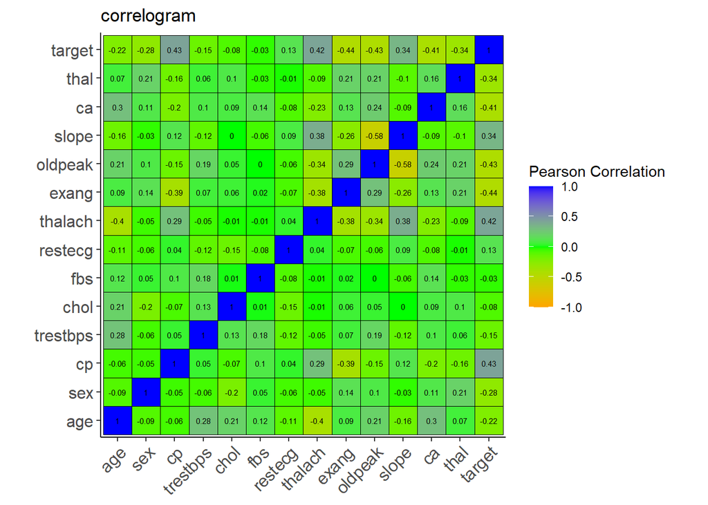

```r
cr <- round(cor(heart), 2) #Store correlation matrix

#Visualize your correlations (Creates a visual heatmap of the correlation matrix)
#install.packages("ggcorrplot")
library(ggcorrplot)
ggcorrplot(cr,title = "correlogram",lab_col = "black",
           lab = TRUE, legend.title = "Pearson Correlation",
           lab_size = 2, ggtheme = theme_classic(),
           outline.color = "black",
           colors = c("orange", "green", "blue"))
```

# Step 4: Data Distribution Visualizations

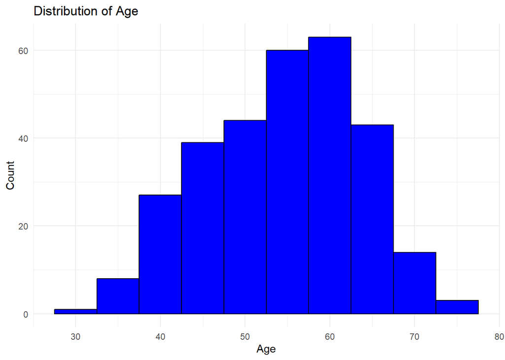

```r
# A. Visualize Numerical Features
library(ggplot2)

# Histogram for Age
ggplot(heart, aes(x = age)) +
  geom_histogram(binwidth = 5, fill = "blue", color = "black") +
  labs(title = "Distribution of Age", x = "Age", y = "Count") +
  theme_minimal()
```

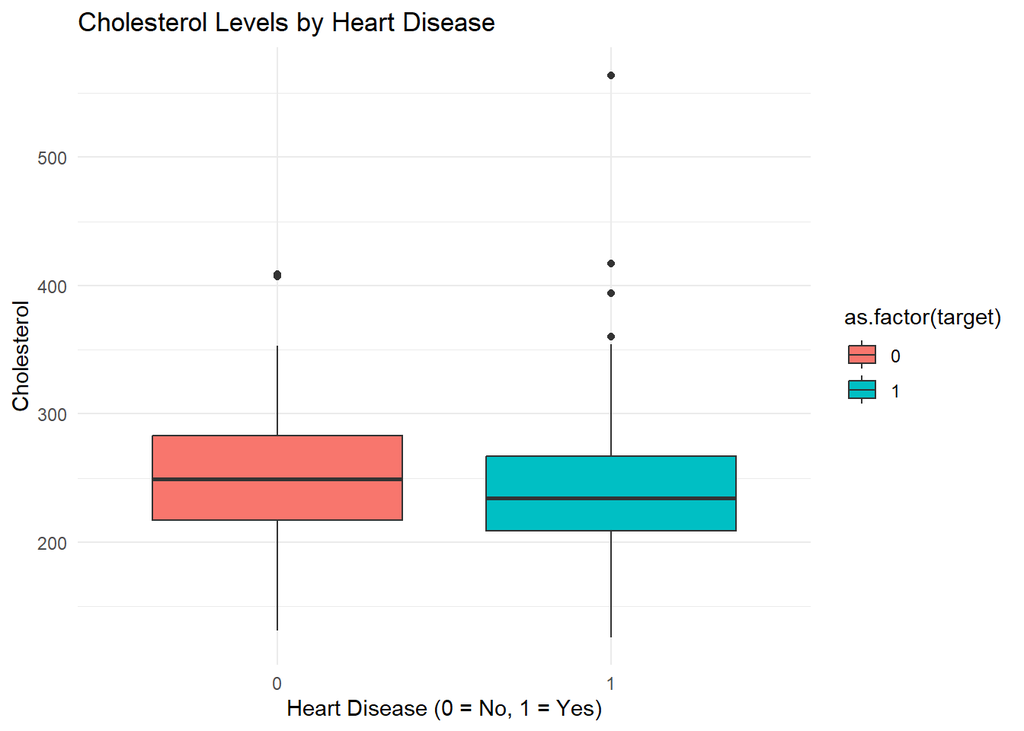

```r
# Boxplot for Cholesterol by Target
ggplot(heart, aes(x = as.factor(target), y = chol, fill = as.factor(target))) +
  geom_boxplot() +
  labs(title = "Cholesterol Levels by Heart Disease", x = "Heart Disease (0 = No, 1 = Yes)", y = "Cholesterol") +
  theme_minimal()
```

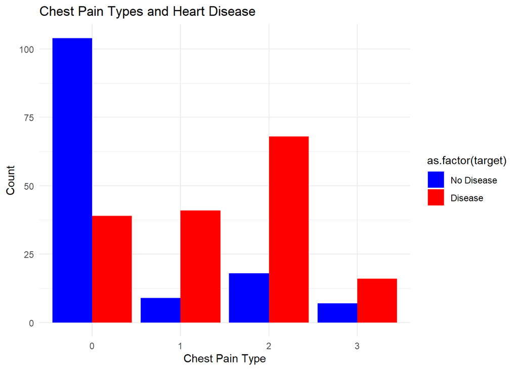

```r
# B. Bar Charts for Categorical Variables

# Bar Chart for Chest Pain Type
ggplot(heart, aes(x = as.factor(cp), fill = as.factor(target))) +
  geom_bar(position = "dodge") +
  labs(title = "Chest Pain Types and Heart Disease", x = "Chest Pain Type", y = "Count") +
  scale_fill_manual(values = c("blue", "red"), labels = c("No Disease", "Disease")) +
  theme_minimal()
```

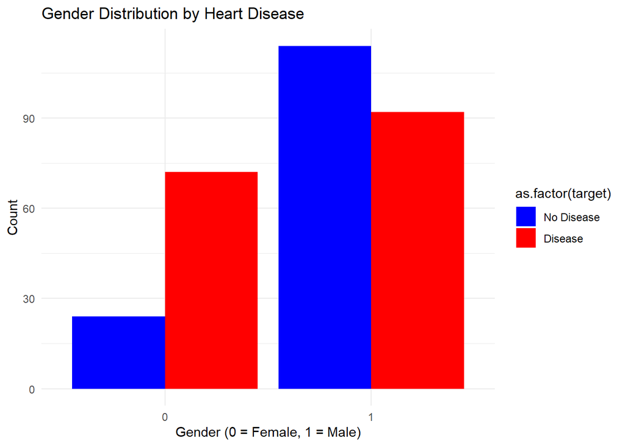

```r
# Gender Distribution
ggplot(heart, aes(x = as.factor(sex), fill = as.factor(target))) +
  geom_bar(position = "dodge") +
  labs(title = "Gender Distribution by Heart Disease", x = "Gender (0 = Female, 1 = Male)", y = "Count") +
  scale_fill_manual(values = c("blue", "red"), labels = c("No Disease", "Disease")) +
  theme_minimal()
```

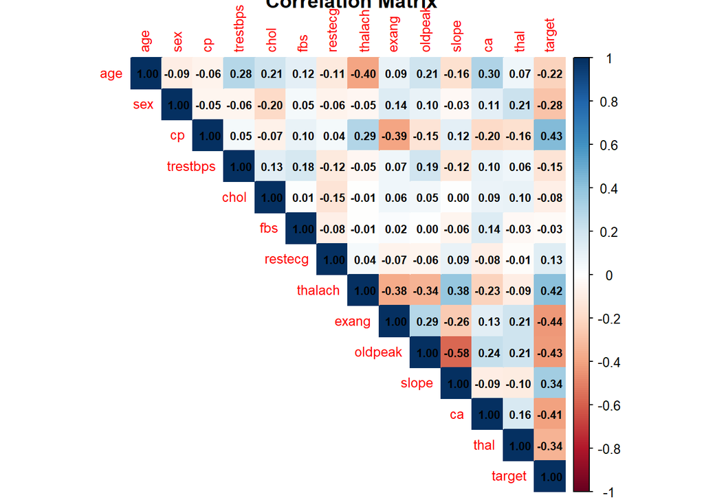

```r
# C. Visualize Relationships Between Numerical Variables
library(corrplot)
# Compute Correlation Matrix
numeric_data <- heart[, sapply(heart, is.numeric)]
cor_matrix <- cor(numeric_data)

# Plot Correlation Heatmap
corrplot(cor_matrix, method = "color", type = "upper",
         addCoef.col = "black", tl.cex = 0.8, number.cex = 0.7,
         main = "Correlation Matrix")
```

# Step 5: Data Transformation (Converting Variables into Factors)

1. Some variables represent categories, not quantities. Treating them as numbers would mislead the model
2. Conversion is important Logistic regression and other models can handle categorical data better when it is encoded as factors. This improves prediction accuracy and Factors make the data more understandable for humans and machines. For instance, sex = Female/Male is clearer than 0/1

```r
heart$sex <- as.factor(heart$sex)
heart$cp <- as.factor(heart$cp)
heart$fbs <- as.factor(heart$fbs)
heart$restecg <- as.factor(heart$restecg)
heart$exang <- as.factor(heart$exang)
heart$slope <- as.factor(heart$slope)
heart$ca <- as.factor(heart$ca)
heart$thal <- as.factor(heart$thal)
heart$target <- as.factor(heart$target)
```

# Step 6: Splitting Data (This step involves dividing the dataset into two parts: training data (80%) and testing data(20%))

Why Split the Data? 1. Training Data (80%): Used to train (build) the model by finding patterns in the data 2. Testing Data (20%): Used to evaluate the model’s accuracy and performance on new, unseen data 3. Reason: This mimics real-world scenarios where the model is applied to data it hasn’t seen before, preventing over fitting (when a model performs well on training data but poorly on new data)

Why Not Use the Entire Data set for Training? 1. Risk of Over fitting: The model might “memorize” the training data, performing exceptionally well on it but failing to generalize to new data 2. Real-World Simulation: In real-life applications, you need the model to work on data it hasn’t seen before

```r
library(caTools)
set.seed(2) #to ensure reproducibility. Without this, every time you split the data, you'll get different results
split <- sample.split(heart$target, SplitRatio = 0.8)
training <- subset(heart, split == TRUE)
testing <- subset(heart, split == FALSE)
```

# Step 7: Building the model (This step involves using the training data to create a mathematical model that predicts the target variable (e.g., presence of heart disease))

1. Here we used logistic regression model because the target variable (target) is binary (0 = no heart disease, 1 = heart disease)

```r
model <- glm(target~., training, family = binomial)
summary(model)
```

```
##
## Call:
## glm(formula = target ~ ., family = binomial, data = training)
##
## Coefficients:
##              Estimate Std. Error z value Pr(>|z|)
## (Intercept)  0.295200   4.353818   0.068 0.945943
## age          0.016480   0.030258   0.545 0.585989
## sex1        -2.624782   0.747849  -3.510 0.000448 ***
## cp1          1.306173   0.714180   1.829 0.067413 .
## cp2          2.596896   0.671185   3.869 0.000109 ***
## cp3          2.920285   0.861528   3.390 0.000700 ***
## trestbps    -0.035263   0.013776  -2.560 0.010474 *
## chol        -0.006496   0.005081  -1.278 0.201115
## fbs1         1.341979   0.831161   1.615 0.106401
## restecg1     0.074422   0.478785   0.155 0.876474
## restecg2    -0.243861   3.353627  -0.073 0.942032
## thalach      0.033606   0.017009   1.976 0.048174 *
## exang1      -0.619649   0.545508  -1.136 0.255993
## oldpeak     -0.409794   0.267555  -1.532 0.125615
## slope1      -0.893167   1.000572  -0.893 0.372041
## slope2       0.861472   1.072122   0.804 0.421674
## ca1         -2.077715   0.649907  -3.197 0.001389 **
## ca2         -3.701530   0.989076  -3.742 0.000182 ***
## ca3         -1.845235   1.123495  -1.642 0.100506
## ca4         -1.084200   3.504617  -0.309 0.757045
## thal1        3.856076   2.968733   1.299 0.193980
## thal2        2.734698   2.856244   0.957 0.338342
## thal3        1.295089   2.852677   0.454 0.649835
## ---
## Signif. codes:  0 '***' 0.001 '**' 0.01 '*' 0.05 '.' 0.1 ' ' 1
##
## (Dispersion parameter for binomial family taken to be 1)
##
##     Null deviance: 332.26  on 240  degrees of freedom
## Residual deviance: 126.82  on 218  degrees of freedom
## AIC: 172.82
##
## Number of Fisher Scoring iterations: 7
```

# Step 8: Model optimization (Model Optimization involves improving the logistic regression model by removing insignificant or redundant variables. This step ensures the model is efficient, interpretable, and performs better on unseen data)

Purpose of Model Optimization 1. Simplify the Model: Reduce complexity by removing unnecessary predictors 2. Improve Performance: Focus on significant predictors to enhance accuracy 3. Lower AIC (Akaike Information Criterion): A lower AIC indicates a better model with an optimal balance of fit and complexity

```r
model <- glm(target~.-age, training, family = binomial)
summary(model)
```

```
##
## Call:
## glm(formula = target ~ . - age, family = binomial, data = training)
##
## Coefficients:
##              Estimate Std. Error z value Pr(>|z|)
## (Intercept)  1.325665   4.011251   0.330 0.741032
## sex1        -2.645056   0.744208  -3.554 0.000379 ***
## cp1          1.314534   0.712747   1.844 0.065136 .
## cp2          2.614185   0.672591   3.887 0.000102 ***
## cp3          2.879652   0.851004   3.384 0.000715 ***
## trestbps    -0.033395   0.013231  -2.524 0.011602 *
## chol        -0.006145   0.004981  -1.234 0.217310
## fbs1         1.315863   0.823644   1.598 0.110129
## restecg1     0.072474   0.479066   0.151 0.879754
## restecg2    -0.203098   3.107969  -0.065 0.947897
## thalach      0.030176   0.015683   1.924 0.054334 .
## exang1      -0.628631   0.543178  -1.157 0.247142
## oldpeak     -0.423506   0.266105  -1.591 0.111497
## slope1      -0.879646   1.000413  -0.879 0.379248
## slope2       0.874920   1.071971   0.816 0.414398
## ca1         -2.029203   0.643416  -3.154 0.001612 **
## ca2         -3.555466   0.944992  -3.762 0.000168 ***
## ca3         -1.760305   1.124240  -1.566 0.117402
## ca4         -1.173104   3.359677  -0.349 0.726960
## thal1        3.911792   3.091294   1.265 0.205720
## thal2        2.791222   2.982312   0.936 0.349311
## thal3        1.356410   2.977998   0.455 0.648766
## ---
## Signif. codes:  0 '***' 0.001 '**' 0.01 '*' 0.05 '.' 0.1 ' ' 1
##
## (Dispersion parameter for binomial family taken to be 1)
##
##     Null deviance: 332.26  on 240  degrees of freedom
## Residual deviance: 127.12  on 219  degrees of freedom
## AIC: 171.12
##
## Number of Fisher Scoring iterations: 7
```

```r
# Remove Insignificant Variables
  # Remove one variable at a time, starting with the least significant
  # Example: If age has a high p-value, it may not significantly predict heart disease in this dataset.
  # Removing it reduces AIC, improving model efficiency

      model <- glm(target~.-chol, training, family = binomial)
      summary(model)
```

```
##
## Call:
## glm(formula = target ~ . - chol, family = binomial, data = training)
##
## Coefficients:
##             Estimate Std. Error z value Pr(>|z|)
## (Intercept) -0.44404    4.24888  -0.105 0.916766
## age          0.01272    0.02959   0.430 0.667287
## sex1        -2.41489    0.71785  -3.364 0.000768 ***
## cp1          1.22038    0.70464   1.732 0.083288 .
## cp2          2.58580    0.66586   3.883 0.000103 ***
## cp3          2.87907    0.85219   3.378 0.000729 ***
## trestbps    -0.03508    0.01383  -2.537 0.011182 *
## fbs1         1.31623    0.81371   1.618 0.105757
## restecg1     0.19375    0.46605   0.416 0.677608
## restecg2    -0.06578    3.01838  -0.022 0.982614
## thalach      0.02989    0.01624   1.840 0.065696 .
## exang1      -0.63343    0.53583  -1.182 0.237144
## oldpeak     -0.42392    0.26841  -1.579 0.114249
## slope1      -0.97229    1.00300  -0.969 0.332354
## slope2       0.78275    1.07296   0.730 0.465681
## ca1         -2.09718    0.65763  -3.189 0.001428 **
## ca2         -3.62163    0.98329  -3.683 0.000230 ***
## ca3         -1.83598    1.10052  -1.668 0.095261 .
## ca4         -1.08181    3.47259  -0.312 0.755400
## thal1        3.75233    2.93266   1.279 0.200723
## thal2        2.56257    2.81508   0.910 0.362663
## thal3        1.02733    2.80375   0.366 0.714057
## ---
## Signif. codes:  0 '***' 0.001 '**' 0.01 '*' 0.05 '.' 0.1 ' ' 1
##
## (Dispersion parameter for binomial family taken to be 1)
##
##     Null deviance: 332.26  on 240  degrees of freedom
## Residual deviance: 128.37  on 219  degrees of freedom
## AIC: 172.37
##
## Number of Fisher Scoring iterations: 7
```

```r
      #Chol should be removed since it reduces aic after removal.

      model <- glm(target~.-fbs, training, family = binomial)
      summary(model)
```

```
##
## Call:
## glm(formula = target ~ . - fbs, family = binomial, data = training)
##
## Coefficients:
##              Estimate Std. Error z value Pr(>|z|)
## (Intercept)  0.707565   4.920003   0.144 0.885647
## age          0.014721   0.030413   0.484 0.628355
## sex1        -2.572096   0.747487  -3.441 0.000580 ***
## cp1          1.209278   0.694549   1.741 0.081666 .
## cp2          2.629193   0.654316   4.018 5.86e-05 ***
## cp3          3.003895   0.864801   3.474 0.000514 ***
## trestbps    -0.032134   0.013221  -2.431 0.015075 *
## chol        -0.006386   0.004972  -1.284 0.199035
## restecg1     0.125134   0.474661   0.264 0.792066
## restecg2    -0.301995   3.265169  -0.092 0.926309
## thalach      0.033734   0.016897   1.996 0.045886 *
## exang1      -0.651458   0.544731  -1.196 0.231725
## oldpeak     -0.436764   0.266089  -1.641 0.100710
## slope1      -0.968080   1.006197  -0.962 0.335990
## slope2       0.679868   1.077629   0.631 0.528111
## ca1         -1.906226   0.618536  -3.082 0.002057 **
## ca2         -3.514953   0.973282  -3.611 0.000304 ***
## ca3         -1.524615   1.046876  -1.456 0.145297
## ca4         -0.522147   4.651809  -0.112 0.910628
## thal1        3.303207   3.755174   0.880 0.379054
## thal2        2.051047   3.663348   0.560 0.575559
## thal3        0.705558   3.670620   0.192 0.847572
## ---
## Signif. codes:  0 '***' 0.001 '**' 0.01 '*' 0.05 '.' 0.1 ' ' 1
##
## (Dispersion parameter for binomial family taken to be 1)
##
##     Null deviance: 332.26  on 240  degrees of freedom
## Residual deviance: 129.54  on 219  degrees of freedom
## AIC: 173.54
##
## Number of Fisher Scoring iterations: 7
```

```r
      #fbs should not be removed since it increases aic after removal

      model <- glm(target~.-restecg, training, family = binomial)
      summary(model)
```

```
##
## Call:
## glm(formula = target ~ . - restecg, family = binomial, data = training)
##
## Coefficients:
##              Estimate Std. Error z value Pr(>|z|)
## (Intercept)  0.363025   4.353294   0.083 0.933541
## age          0.016401   0.030232   0.543 0.587459
## sex1        -2.635390   0.740914  -3.557 0.000375 ***
## cp1          1.315717   0.712078   1.848 0.064644 .
## cp2          2.597341   0.671275   3.869 0.000109 ***
## cp3          2.924994   0.859950   3.401 0.000671 ***
## trestbps    -0.035573   0.013639  -2.608 0.009104 **
## chol        -0.006644   0.004961  -1.339 0.180501
## fbs1         1.346928   0.827585   1.628 0.103622
## thalach      0.033933   0.016907   2.007 0.044748 *
## exang1      -0.621461   0.545736  -1.139 0.254804
## oldpeak     -0.410861   0.265914  -1.545 0.122325
## slope1      -0.893861   0.996916  -0.897 0.369919
## slope2       0.870259   1.066995   0.816 0.414719
## ca1         -2.085554   0.647452  -3.221 0.001277 **
## ca2         -3.706346   0.986647  -3.757 0.000172 ***
## ca3         -1.848735   1.127038  -1.640 0.100933
## ca4         -1.088224   3.450364  -0.315 0.752463
## thal1        3.878334   3.008006   1.289 0.197281
## thal2        2.736131   2.900255   0.943 0.345471
## thal3        1.308902   2.894590   0.452 0.651133
## ---
## Signif. codes:  0 '***' 0.001 '**' 0.01 '*' 0.05 '.' 0.1 ' ' 1
##
## (Dispersion parameter for binomial family taken to be 1)
##
##     Null deviance: 332.26  on 240  degrees of freedom
## Residual deviance: 126.85  on 220  degrees of freedom
## AIC: 168.85
##
## Number of Fisher Scoring iterations: 7
```